# Lecture 07

March 4, 2016

## Accuracy vs Precision

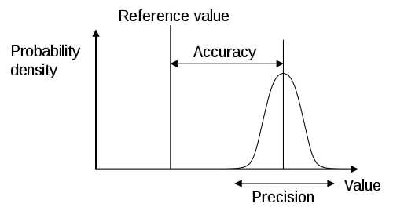

## Analogy: Aiming for Top Right

[figure not shown]

## High Precision, Low Accuracy

[figure not shown]

## Low Precision, High Accuracy

[figure not shown]

## Sampling Dist'n of \(\overline{X}\) for Normal Obs.

Let \(\vec{X} = (X_1, \ldots, X_n)\) be IID Normal\((\mu=5, \sigma=2)\) RV.

Compare 1000 instances of \(\overline{x}\) when

- \(n=100\). \(SE = \frac{2}{\sqrt{100}} = 0.2\)
- \(n=1000\). \(SE = \frac{2}{\sqrt{1000}} = 0.0632\)

Let's pretend that we don't know that \(\mu=5\) for sake of discussion, i.e. we are trying to estimate it.

## Sampling Dist'n of \(\overline{X}\) for Normal Obs.

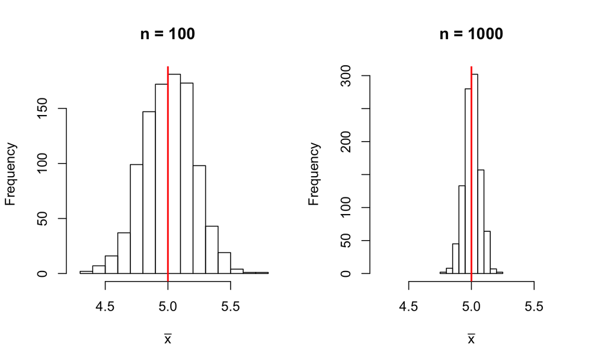

## Sampling Dist'n of \(\overline{X}\) for Normal Obs.

For the larger \(n\)

- the SE is smaller
- i.e. there is less varibility in the \(\overline{x}\)
- i.e. we have more precision
- i.e. our estimates \(\overline{x}\) tend to be closer to the true population mean \(\mu=5\).

## Central Limit Theorem

Say you have a wacky **population distribution** with \(\mu\) in red:

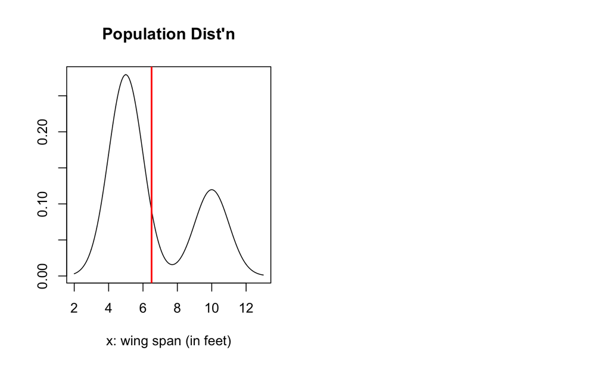

## Central Limit Theorem

Irregardless, the distribution of \(\overline{x}\) will be normal if \(n\) is large:

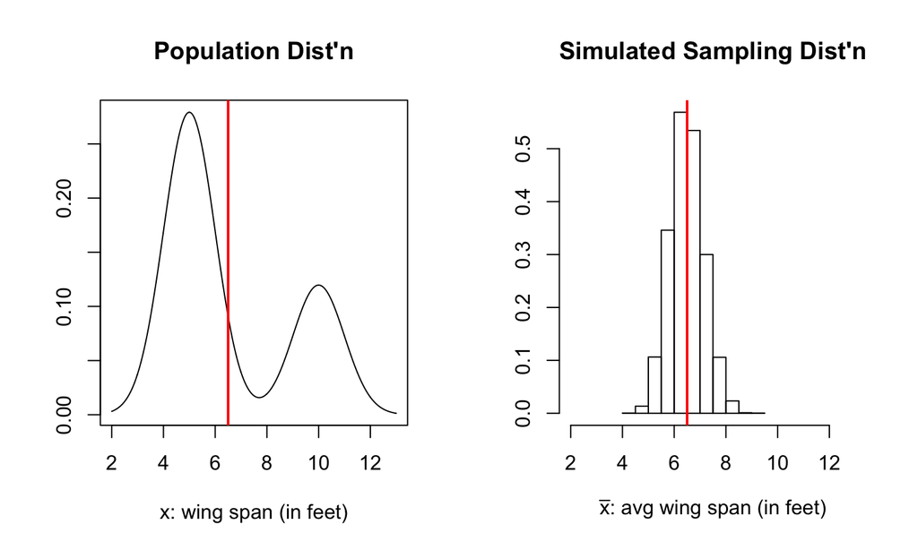

## Wacky Example

Say you have another wacky population distribution \(f(x)\)

\[ f(x) = \left\{ \begin{array}{ll} \exp(x)/2 & \mbox{for } x < 0 \\ 0 & \mbox{for } 0 \leq x < 7 \\ \exp(7-x)/2 & \mbox{for } x \geq 7 \\ \end{array} \right. \]

## Wacky Example

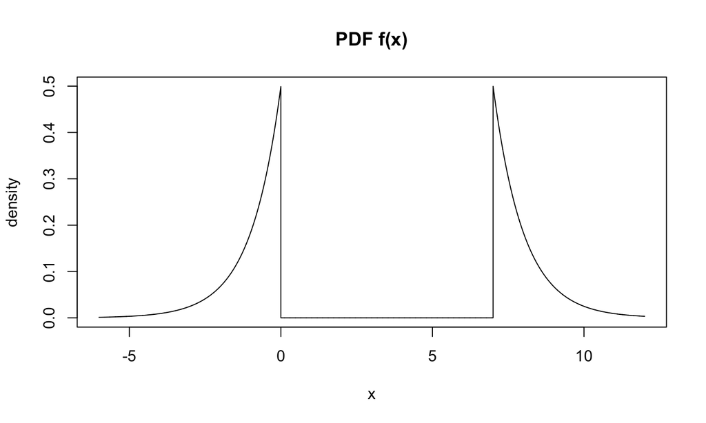

## Wacky Example

Now let's **simulate** the sampling distribution of \(\overline{X}\) (using 10000 simulations) for different values of \(n\):

- 1
- 2
- 4
- 6
- 10
- 25

## Wacky Example

When \(n=1\), simulating from the sampling dist'n is the same as simulating from the population dist'n since \(\overline{x} = x_1\)

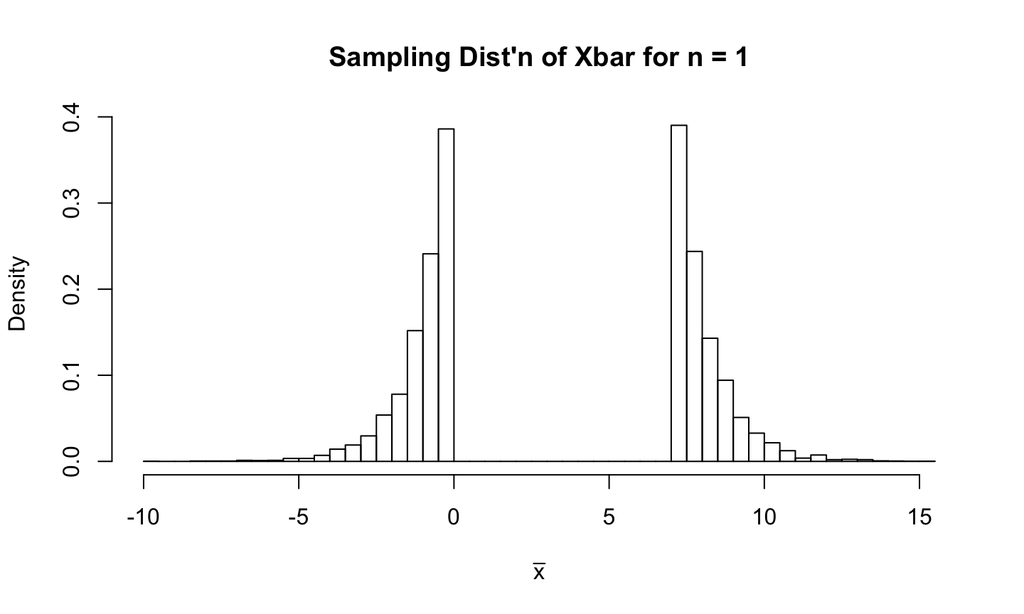

## Wacky Example

For \(n=2\), 3 modes appear based on where \(X_1, X_2\) come from: 1) both the left, 2) one left and one right, and 3) both from right.

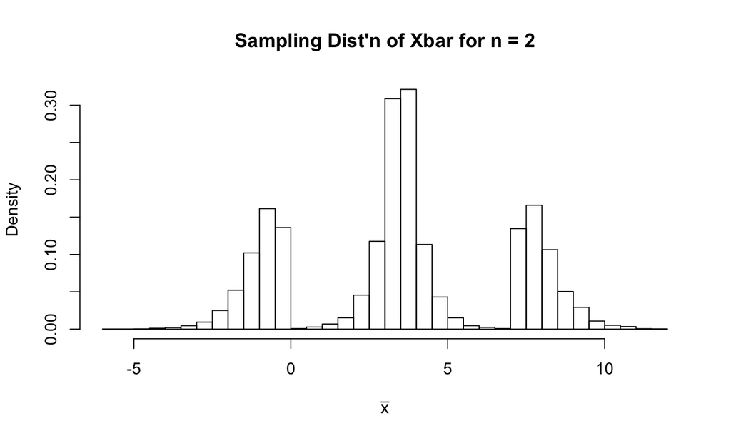

## Wacky Example

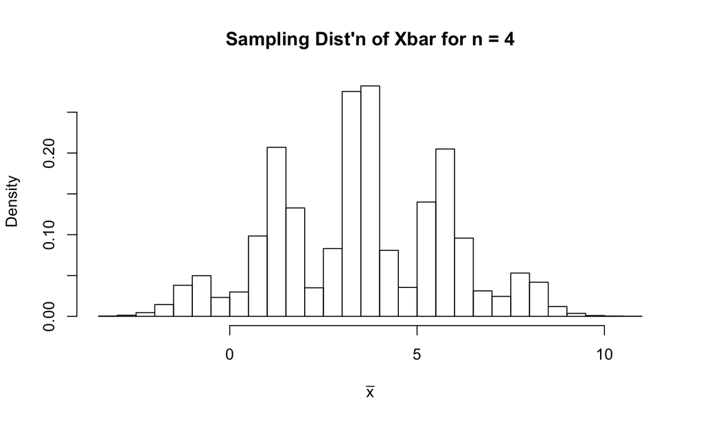

## Wacky Example

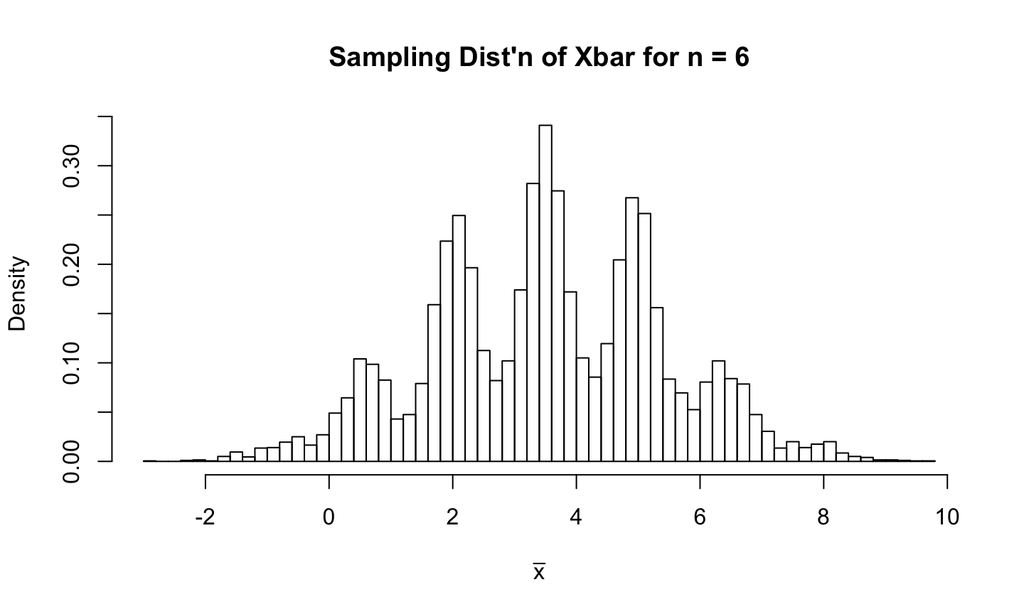

## Wacky Example

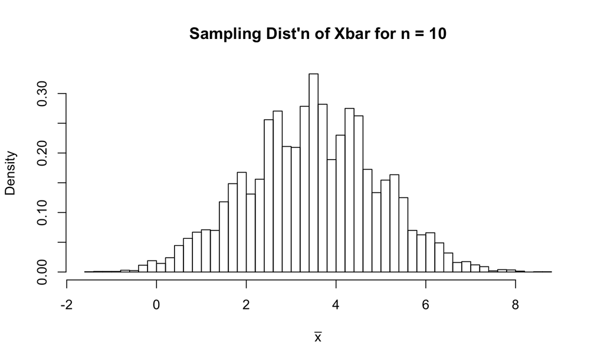

## Wacky Example

By \(n=25\) the approximation looks pretty good…

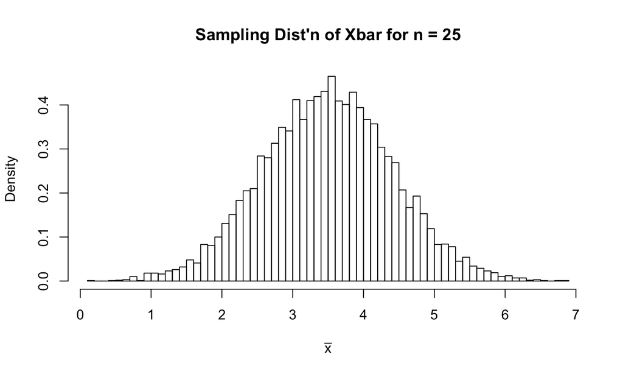

## Wacky Example

…as evidenced by a superimposed normal curve.

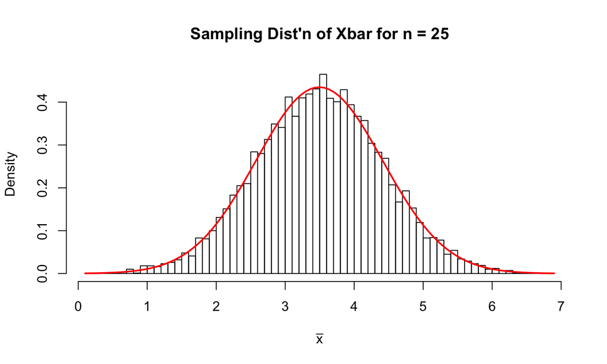